# Neural Networks

Master in Artificial Intelligence and Data Science A.A. 2023/2024

Author

Gaudio Marco

Published

July 1, 2024

Questo progetto accademico ha l’obiettivo di sviluppare dei modelli di Neural Networks per la previsione del diabete utilizzando il dataset **Pima Indians Diabetes**. Il dataset, ampiamente riconosciuto e utilizzato nella comunità scientifica, contiene informazioni diagnostiche su pazienti di etnia Pima, inclusi parametri medici e anagrafici. L’obiettivo del progetto è sviluppare un modello di rete neurale accurato in grado di classificare i pazienti come diabetici o non diabetici, basandosi sulle caratteristiche fornite. Questo progetto, esplora varie tecniche di pre-processing dei dati, come la normalizzazione, nonché l’implementazione di componenti avanzati della rete neurale, inclusi diversi tipi di funzioni di attivazione, tecniche di regolarizzazione e ottimizzatori.

# 1 Setup environment e librerie

Nel seguente chunk di codice sono stati utilizzati i pacchetti `tensorflow` e `keras` per creare un enviroment che permetta di utilizzare tutte le funzionalità di ML native dei due framework di python.

```r
# unlink(paste0(reticulate::virtualenv_root(), "/r-tensorflow"), force = TRUE, recursive = TRUE)
library(tensorflow)
# install_tensorflow(envname = "r-tensorflow")

# install.packages("keras")
library(keras)
# install_keras()
```

# 2 Analisi dati

Il dataset contiene 768 righe e 9 colonne. Ogni riga rappresenta un paziente, e ogni colonna rappresenta una caratteristica (ad eccezione dell’ultima colonna, che è l’etichetta di classe). Le caratteristiche sono le seguenti:

- Numero di gravidanze - `V1`
- Concentrazione di glucosio nel sangue a 2 ore nel test di tolleranza orale al glucosio -`V2`
- Pressione diastolica del sangue (mm Hg) - `V3`
- Spessore della piega cutanea del tricipite (mm) - `V4`
- Insulina sierica a 2 ore (mu U/ml) - `V5`
- Indice di massa corporea (peso in kg / (altezza in m)^2) - `V6`
- Funzione della storia familiare del diabete (valore ponderato) - `V7`
- Età (anni) - `V8`
- Diagnosi (0 o 1, dove 1 indica la presenza di diabete) - `V9`

```r
diabetes <- read.csv("./data/pima-indians-diabetes.data.csv", header = F)

# conversione dei dati in formato data.frame
diabetes <- as.data.frame(diabetes)
```

## 2.1 Preparazione dataset

Utilizzo il pacchetto `caret` per effettuare la divisione tra train set (60%) e test set (40%).

```r
train_index <- caret::createDataPartition(
  diabetes$V9,
  p = 0.6
  )

train <- diabetes[train_index$Resample1, ]
test <-  diabetes[-train_index$Resample1, ]
```

# 3 Analisi esplorativa dei dati

Questa sezione include la valutazione delle distribuzioni delle variabili, l’analisi delle correlazioni, l’individuazione di outlier e la verifica di eventuali anomalie, tutte operazioni fondamentali per costruire modelli predittivi accurati e affidabili.

## 3.1 split per diagnosi (0/1)

La tabella di seguito mostra lo split delle osservazioni per diagnosi. Si noti che circa il 35% dei pazienti presenti all’interno del database è affetto da diabete.

|  | V9 | n | percentage |
| --- | --- | --- | --- |
| 1 | 0 | 500 | 65.1% |
| 2 | 1 | 268 | 34.9% |

## 3.2 Distribuzioni

Nel tabset di seguito sono rappresentate le distribuzioni di alcune delle variabili del dataset in oggetto.

**per età**

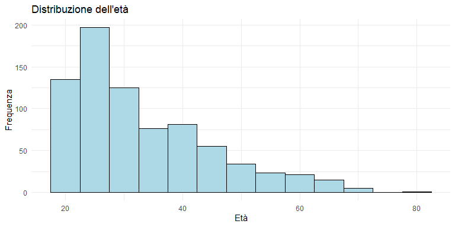

**per numero di gravidanze**

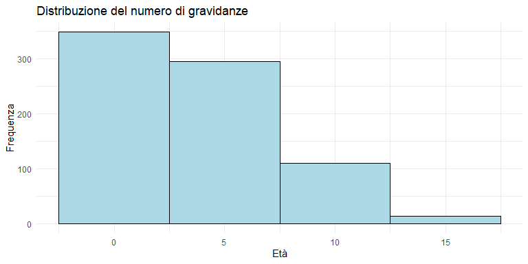

[figure not shown]

## 3.3 Analisi di correlazione

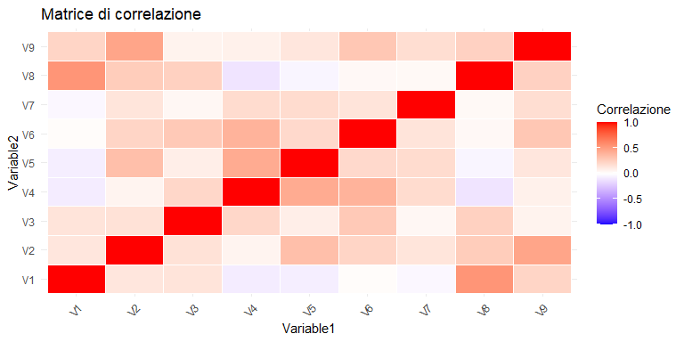

# 4 Modelli

In questa sezione vengono addestrate le varie reti neurali. Sono state utilizzate diverse configurazioni, modificando il numero di nodi, il numero di layer nascosti, le funzioni di attivazione e utilizzando alcune tecniche per prevenire l’overfitting.

Tuttavia, per quanto riguarda l’ottimizzazione dell’addestramento e la misura di accuratezza, per tutti i modelli sono stati utilizzati rispettivamente **l’adam optimizer** e la **binary crossentropy**. Infine, come funzione di attivazione del layer terminale, viene utilizzata sempre la *sigmoid*.

## 4.1 Normalizzazione dei dati

La normalizzazione dei dati è un passaggio fondamentale nel pre-processing quando si utilizzano reti neurali per diverse ragioni:

- Miglioramento della stabilità numerica;
- Riduzione della dipendenza dalla scala degli input delle features;
- Uniformità delle caratteristiche.

Per tale motivo, prima di effettuare qualsiasi analisi, si procede con la normalizzazione dei dati (min-max scaler normalization).

```r
# Min-max scaler

x_train <- train[ , -dim(train)[2]]
y_train <- train[ , dim(train)[2]]

x_test <- test[ , -dim(test)[2]]
y_test <- test[ , dim(test)[2]]

# Creo un oggetto preProcess
preProcess_range_model <- caret::preProcess(x_train, method = 'range')

# Transformo i dati di train
x_train <- predict(preProcess_range_model, x_train)

# Transformo i dati di test
x_test <- as.matrix(predict(preProcess_range_model, x_test))

# ridimensiono il training set
# x_train <- keras::array_reshape(x_train, c(461, 8))
x_train <- as.matrix(x_train)
y_train <- keras::array_reshape(y_train, c(461, 1))
```

## 4.2 Fit del modello A

```r
# Struttura della rete
network_A <- keras::keras_model_sequential() %>%
  keras::layer_dense(units = 32,
              activation = "relu",
              input_shape = dim(x_train)[2]) %>%
  keras::layer_dense(units = 16,
              activation = "relu",
              ) %>%
  keras::layer_dense(units = 1,
              activation = "sigmoid"
              )
```

```r
# Compilazione della rete
network_A %>% compile(
  optimizer = "adam",
  loss = "binary_crossentropy",
  metrics = "accuracy"
)
```

```r
# Addestramento della rete
fit_A <- network_A %>%
  fit(x_train, y_train,
                epochs = 80, batch_size = 32, validation_split = 0.3)
```

```
11/11 - 1s - loss: 0.6822 - accuracy: 0.6273 - val_loss: 0.6746 - val_accuracy: 0.6475 - 1s/epoch - 119ms/step
11/11 - 0s - loss: 0.6761 - accuracy: 0.6273 - val_loss: 0.6692 - val_accuracy: 0.6475 - 100ms/epoch - 9ms/step
11/11 - 0s - loss: 0.6727 - accuracy: 0.6273 - val_loss: 0.6675 - val_accuracy: 0.6475 - 63ms/epoch - 6ms/step
11/11 - 0s - loss: 0.6713 - accuracy: 0.6273 - val_loss: 0.6666 - val_accuracy: 0.6403 - 84ms/epoch - 8ms/step
11/11 - 0s - loss: 0.6693 - accuracy: 0.6335 - val_loss: 0.6627 - val_accuracy: 0.6403 - 69ms/epoch - 6ms/step
11/11 - 0s - loss: 0.6655 - accuracy: 0.6304 - val_loss: 0.6574 - val_accuracy: 0.6475 - 85ms/epoch - 8ms/step
11/11 - 0s - loss: 0.6618 - accuracy: 0.6304 - val_loss: 0.6540 - val_accuracy: 0.6475 - 78ms/epoch - 7ms/step
11/11 - 0s - loss: 0.6589 - accuracy: 0.6304 - val_loss: 0.6501 - val_accuracy: 0.6475 - 85ms/epoch - 8ms/step
11/11 - 0s - loss: 0.6557 - accuracy: 0.6335 - val_loss: 0.6479 - val_accuracy: 0.6475 - 69ms/epoch - 6ms/step
11/11 - 0s - loss: 0.6522 - accuracy: 0.6398 - val_loss: 0.6441 - val_accuracy: 0.6547 - 100ms/epoch - 9ms/step
11/11 - 0s - loss: 0.6485 - accuracy: 0.6429 - val_loss: 0.6397 - val_accuracy: 0.6547 - 85ms/epoch - 8ms/step
11/11 - 0s - loss: 0.6456 - accuracy: 0.6460 - val_loss: 0.6366 - val_accuracy: 0.6547 - 85ms/epoch - 8ms/step
11/11 - 0s - loss: 0.6420 - accuracy: 0.6553 - val_loss: 0.6330 - val_accuracy: 0.6547 - 85ms/epoch - 8ms/step
11/11 - 0s - loss: 0.6388 - accuracy: 0.6584 - val_loss: 0.6292 - val_accuracy: 0.6547 - 96ms/epoch - 9ms/step
11/11 - 0s - loss: 0.6355 - accuracy: 0.6522 - val_loss: 0.6221 - val_accuracy: 0.6547 - 78ms/epoch - 7ms/step
11/11 - 0s - loss: 0.6286 - accuracy: 0.6584 - val_loss: 0.6168 - val_accuracy: 0.6547 - 85ms/epoch - 8ms/step
11/11 - 0s - loss: 0.6240 - accuracy: 0.6832 - val_loss: 0.6173 - val_accuracy: 0.6978 - 85ms/epoch - 8ms/step
11/11 - 0s - loss: 0.6189 - accuracy: 0.6832 - val_loss: 0.6064 - val_accuracy: 0.6835 - 100ms/epoch - 9ms/step
11/11 - 0s - loss: 0.6120 - accuracy: 0.6832 - val_loss: 0.5982 - val_accuracy: 0.7050 - 85ms/epoch - 8ms/step
11/11 - 0s - loss: 0.6047 - accuracy: 0.6832 - val_loss: 0.5906 - val_accuracy: 0.7266 - 85ms/epoch - 8ms/step
11/11 - 0s - loss: 0.5968 - accuracy: 0.7174 - val_loss: 0.5865 - val_accuracy: 0.7410 - 69ms/epoch - 6ms/step
11/11 - 0s - loss: 0.5926 - accuracy: 0.7329 - val_loss: 0.5814 - val_accuracy: 0.7194 - 69ms/epoch - 6ms/step
11/11 - 0s - loss: 0.5913 - accuracy: 0.7019 - val_loss: 0.5751 - val_accuracy: 0.7410 - 63ms/epoch - 6ms/step
11/11 - 0s - loss: 0.5824 - accuracy: 0.7174 - val_loss: 0.5712 - val_accuracy: 0.7410 - 69ms/epoch - 6ms/step
11/11 - 0s - loss: 0.5777 - accuracy: 0.7360 - val_loss: 0.5673 - val_accuracy: 0.7338 - 69ms/epoch - 6ms/step
11/11 - 0s - loss: 0.5749 - accuracy: 0.7329 - val_loss: 0.5671 - val_accuracy: 0.7554 - 84ms/epoch - 8ms/step
11/11 - 0s - loss: 0.5694 - accuracy: 0.7298 - val_loss: 0.5567 - val_accuracy: 0.7266 - 78ms/epoch - 7ms/step
11/11 - 0s - loss: 0.5638 - accuracy: 0.7453 - val_loss: 0.5542 - val_accuracy: 0.7554 - 63ms/epoch - 6ms/step
11/11 - 0s - loss: 0.5607 - accuracy: 0.7298 - val_loss: 0.5481 - val_accuracy: 0.7338 - 85ms/epoch - 8ms/step
11/11 - 0s - loss: 0.5545 - accuracy: 0.7329 - val_loss: 0.5412 - val_accuracy: 0.7266 - 69ms/epoch - 6ms/step
11/11 - 0s - loss: 0.5524 - accuracy: 0.7298 - val_loss: 0.5384 - val_accuracy: 0.7410 - 85ms/epoch - 8ms/step
11/11 - 0s - loss: 0.5486 - accuracy: 0.7298 - val_loss: 0.5347 - val_accuracy: 0.7266 - 78ms/epoch - 7ms/step
11/11 - 0s - loss: 0.5486 - accuracy: 0.7391 - val_loss: 0.5415 - val_accuracy: 0.7626 - 69ms/epoch - 6ms/step
11/11 - 0s - loss: 0.5414 - accuracy: 0.7391 - val_loss: 0.5280 - val_accuracy: 0.7554 - 69ms/epoch - 6ms/step
11/11 - 0s - loss: 0.5336 - accuracy: 0.7329 - val_loss: 0.5236 - val_accuracy: 0.7626 - 100ms/epoch - 9ms/step
11/11 - 0s - loss: 0.5274 - accuracy: 0.7453 - val_loss: 0.5142 - val_accuracy: 0.7338 - 100ms/epoch - 9ms/step
11/11 - 0s - loss: 0.5289 - accuracy: 0.7360 - val_loss: 0.5097 - val_accuracy: 0.7338 - 85ms/epoch - 8ms/step
11/11 - 0s - loss: 0.5193 - accuracy: 0.7484 - val_loss: 0.5086 - val_accuracy: 0.7698 - 100ms/epoch - 9ms/step
11/11 - 0s - loss: 0.5143 - accuracy: 0.7453 - val_loss: 0.4973 - val_accuracy: 0.7554 - 87ms/epoch - 8ms/step
11/11 - 0s - loss: 0.5185 - accuracy: 0.7484 - val_loss: 0.4957 - val_accuracy: 0.7410 - 74ms/epoch - 7ms/step
```

[output cut: 25 more lines]

```
11/11 - 0s - loss: 0.4574 - accuracy: 0.7857 - val_loss: 0.4391 - val_accuracy: 0.7914 - 100ms/epoch - 9ms/step
11/11 - 0s - loss: 0.4618 - accuracy: 0.7795 - val_loss: 0.4339 - val_accuracy: 0.7986 - 78ms/epoch - 7ms/step
11/11 - 0s - loss: 0.4596 - accuracy: 0.7764 - val_loss: 0.4406 - val_accuracy: 0.8345 - 85ms/epoch - 8ms/step
11/11 - 0s - loss: 0.4574 - accuracy: 0.7764 - val_loss: 0.4292 - val_accuracy: 0.7986 - 85ms/epoch - 8ms/step
11/11 - 0s - loss: 0.4515 - accuracy: 0.7888 - val_loss: 0.4269 - val_accuracy: 0.8058 - 101ms/epoch - 9ms/step
11/11 - 0s - loss: 0.4503 - accuracy: 0.7857 - val_loss: 0.4265 - val_accuracy: 0.8201 - 84ms/epoch - 8ms/step
11/11 - 0s - loss: 0.4467 - accuracy: 0.8012 - val_loss: 0.4246 - val_accuracy: 0.8201 - 85ms/epoch - 8ms/step
11/11 - 0s - loss: 0.4456 - accuracy: 0.7981 - val_loss: 0.4231 - val_accuracy: 0.8345 - 81ms/epoch - 7ms/step
11/11 - 0s - loss: 0.4455 - accuracy: 0.7826 - val_loss: 0.4225 - val_accuracy: 0.8201 - 63ms/epoch - 6ms/step
11/11 - 0s - loss: 0.4424 - accuracy: 0.7888 - val_loss: 0.4225 - val_accuracy: 0.8129 - 84ms/epoch - 8ms/step
11/11 - 0s - loss: 0.4443 - accuracy: 0.7981 - val_loss: 0.4179 - val_accuracy: 0.8201 - 100ms/epoch - 9ms/step
11/11 - 0s - loss: 0.4403 - accuracy: 0.7981 - val_loss: 0.4182 - val_accuracy: 0.8273 - 85ms/epoch - 8ms/step
11/11 - 0s - loss: 0.4419 - accuracy: 0.8106 - val_loss: 0.4174 - val_accuracy: 0.8345 - 100ms/epoch - 9ms/step
11/11 - 0s - loss: 0.4391 - accuracy: 0.8075 - val_loss: 0.4174 - val_accuracy: 0.8201 - 85ms/epoch - 8ms/step
11/11 - 0s - loss: 0.4469 - accuracy: 0.8106 - val_loss: 0.4239 - val_accuracy: 0.8345 - 85ms/epoch - 8ms/step
```

## 4.3 Fit del modello B

```r
# Struttura della rete
network_B <- keras::keras_model_sequential() %>%
  keras::layer_dense(units = 128,
              activation = "relu",
              input_shape = dim(x_train)[2]) %>%
  keras::layer_dense(units = 64,
              activation = "relu"
              ) %>%
  keras::layer_dense(units = 32,
              activation = "relu"
              ) %>%
  keras::layer_dense(units = 1,
              activation = "sigmoid"
              )
```

```r
# Compilazione della rete
network_B %>% compile(
  optimizer = "adam",
  loss = "binary_crossentropy",
  metrics = "accuracy"
)
```

```r
# Addestramento della rete
fit_B <- network_B %>%
  fit(x_train, y_train,
                epochs = 150, batch_size = 32, validation_split = 0.3)
```

```
11/11 - 1s - loss: 0.6847 - accuracy: 0.5807 - val_loss: 0.6667 - val_accuracy: 0.6475 - 1s/epoch - 110ms/step
11/11 - 0s - loss: 0.6659 - accuracy: 0.6273 - val_loss: 0.6546 - val_accuracy: 0.6475 - 78ms/epoch - 7ms/step
11/11 - 0s - loss: 0.6616 - accuracy: 0.6273 - val_loss: 0.6438 - val_accuracy: 0.6475 - 85ms/epoch - 8ms/step
11/11 - 0s - loss: 0.6544 - accuracy: 0.6491 - val_loss: 0.6397 - val_accuracy: 0.6403 - 85ms/epoch - 8ms/step
11/11 - 0s - loss: 0.6411 - accuracy: 0.6522 - val_loss: 0.6264 - val_accuracy: 0.6475 - 85ms/epoch - 8ms/step
11/11 - 0s - loss: 0.6313 - accuracy: 0.6491 - val_loss: 0.6167 - val_accuracy: 0.6331 - 69ms/epoch - 6ms/step
11/11 - 0s - loss: 0.6286 - accuracy: 0.6832 - val_loss: 0.6075 - val_accuracy: 0.7266 - 78ms/epoch - 7ms/step
11/11 - 0s - loss: 0.6090 - accuracy: 0.7019 - val_loss: 0.5925 - val_accuracy: 0.6547 - 85ms/epoch - 8ms/step
11/11 - 0s - loss: 0.5998 - accuracy: 0.6801 - val_loss: 0.5771 - val_accuracy: 0.7122 - 85ms/epoch - 8ms/step
11/11 - 0s - loss: 0.5862 - accuracy: 0.6988 - val_loss: 0.5628 - val_accuracy: 0.7194 - 96ms/epoch - 9ms/step
11/11 - 0s - loss: 0.5696 - accuracy: 0.7267 - val_loss: 0.5482 - val_accuracy: 0.7482 - 72ms/epoch - 7ms/step
11/11 - 0s - loss: 0.5588 - accuracy: 0.7081 - val_loss: 0.5258 - val_accuracy: 0.7338 - 85ms/epoch - 8ms/step
11/11 - 0s - loss: 0.5449 - accuracy: 0.7453 - val_loss: 0.5249 - val_accuracy: 0.7266 - 100ms/epoch - 9ms/step
11/11 - 0s - loss: 0.5305 - accuracy: 0.7360 - val_loss: 0.5022 - val_accuracy: 0.7338 - 78ms/epoch - 7ms/step
11/11 - 0s - loss: 0.5266 - accuracy: 0.7391 - val_loss: 0.4934 - val_accuracy: 0.7554 - 69ms/epoch - 6ms/step
11/11 - 0s - loss: 0.5421 - accuracy: 0.7298 - val_loss: 0.4912 - val_accuracy: 0.7554 - 85ms/epoch - 8ms/step
11/11 - 0s - loss: 0.5490 - accuracy: 0.7205 - val_loss: 0.4979 - val_accuracy: 0.7986 - 85ms/epoch - 8ms/step
11/11 - 0s - loss: 0.5125 - accuracy: 0.7609 - val_loss: 0.4940 - val_accuracy: 0.7554 - 85ms/epoch - 8ms/step
11/11 - 0s - loss: 0.5104 - accuracy: 0.7391 - val_loss: 0.4943 - val_accuracy: 0.7770 - 63ms/epoch - 6ms/step
11/11 - 0s - loss: 0.4980 - accuracy: 0.7578 - val_loss: 0.4715 - val_accuracy: 0.7482 - 69ms/epoch - 6ms/step
11/11 - 0s - loss: 0.5075 - accuracy: 0.7702 - val_loss: 0.4635 - val_accuracy: 0.7842 - 69ms/epoch - 6ms/step
11/11 - 0s - loss: 0.4956 - accuracy: 0.7453 - val_loss: 0.4708 - val_accuracy: 0.8058 - 94ms/epoch - 9ms/step
11/11 - 0s - loss: 0.4699 - accuracy: 0.7950 - val_loss: 0.4628 - val_accuracy: 0.7698 - 73ms/epoch - 7ms/step
11/11 - 0s - loss: 0.4758 - accuracy: 0.7826 - val_loss: 0.4349 - val_accuracy: 0.8201 - 78ms/epoch - 7ms/step
11/11 - 0s - loss: 0.4695 - accuracy: 0.7733 - val_loss: 0.4268 - val_accuracy: 0.8058 - 69ms/epoch - 6ms/step
11/11 - 0s - loss: 0.4645 - accuracy: 0.7795 - val_loss: 0.4308 - val_accuracy: 0.8058 - 69ms/epoch - 6ms/step
11/11 - 0s - loss: 0.4572 - accuracy: 0.8012 - val_loss: 0.4261 - val_accuracy: 0.8201 - 69ms/epoch - 6ms/step
11/11 - 0s - loss: 0.4592 - accuracy: 0.7671 - val_loss: 0.4147 - val_accuracy: 0.8201 - 78ms/epoch - 7ms/step
11/11 - 0s - loss: 0.4541 - accuracy: 0.7826 - val_loss: 0.4325 - val_accuracy: 0.7914 - 85ms/epoch - 8ms/step
11/11 - 0s - loss: 0.4700 - accuracy: 0.7826 - val_loss: 0.4118 - val_accuracy: 0.8273 - 69ms/epoch - 6ms/step
11/11 - 0s - loss: 0.4378 - accuracy: 0.8043 - val_loss: 0.4042 - val_accuracy: 0.8201 - 100ms/epoch - 9ms/step
11/11 - 0s - loss: 0.4345 - accuracy: 0.7950 - val_loss: 0.4019 - val_accuracy: 0.8201 - 85ms/epoch - 8ms/step
11/11 - 0s - loss: 0.4302 - accuracy: 0.8012 - val_loss: 0.4127 - val_accuracy: 0.8273 - 69ms/epoch - 6ms/step
11/11 - 0s - loss: 0.4319 - accuracy: 0.7888 - val_loss: 0.4048 - val_accuracy: 0.8345 - 90ms/epoch - 8ms/step
11/11 - 0s - loss: 0.4238 - accuracy: 0.7981 - val_loss: 0.3956 - val_accuracy: 0.8201 - 70ms/epoch - 6ms/step
11/11 - 0s - loss: 0.4338 - accuracy: 0.8012 - val_loss: 0.3987 - val_accuracy: 0.8129 - 88ms/epoch - 8ms/step
11/11 - 0s - loss: 0.4160 - accuracy: 0.8106 - val_loss: 0.3912 - val_accuracy: 0.8201 - 85ms/epoch - 8ms/step
11/11 - 0s - loss: 0.4322 - accuracy: 0.7888 - val_loss: 0.3971 - val_accuracy: 0.8201 - 69ms/epoch - 6ms/step
11/11 - 0s - loss: 0.4196 - accuracy: 0.8075 - val_loss: 0.3873 - val_accuracy: 0.8129 - 78ms/epoch - 7ms/step
11/11 - 0s - loss: 0.4273 - accuracy: 0.8012 - val_loss: 0.3879 - val_accuracy: 0.8058 - 85ms/epoch - 8ms/step
```

[output cut: 95 more lines]

```
11/11 - 0s - loss: 0.2774 - accuracy: 0.8634 - val_loss: 0.4528 - val_accuracy: 0.7770 - 94ms/epoch - 9ms/step
11/11 - 0s - loss: 0.2750 - accuracy: 0.8820 - val_loss: 0.4545 - val_accuracy: 0.7626 - 85ms/epoch - 8ms/step
11/11 - 0s - loss: 0.2958 - accuracy: 0.8696 - val_loss: 0.5040 - val_accuracy: 0.7554 - 85ms/epoch - 8ms/step
11/11 - 0s - loss: 0.3018 - accuracy: 0.8696 - val_loss: 0.4907 - val_accuracy: 0.7626 - 85ms/epoch - 8ms/step
11/11 - 0s - loss: 0.3075 - accuracy: 0.8354 - val_loss: 0.4700 - val_accuracy: 0.7698 - 69ms/epoch - 6ms/step
11/11 - 0s - loss: 0.2885 - accuracy: 0.8758 - val_loss: 0.4655 - val_accuracy: 0.7770 - 100ms/epoch - 9ms/step
11/11 - 0s - loss: 0.2727 - accuracy: 0.8882 - val_loss: 0.4552 - val_accuracy: 0.7626 - 85ms/epoch - 8ms/step
11/11 - 0s - loss: 0.2854 - accuracy: 0.8665 - val_loss: 0.4966 - val_accuracy: 0.7554 - 78ms/epoch - 7ms/step
11/11 - 0s - loss: 0.3259 - accuracy: 0.8416 - val_loss: 0.4366 - val_accuracy: 0.7914 - 69ms/epoch - 6ms/step
11/11 - 0s - loss: 0.3005 - accuracy: 0.8602 - val_loss: 0.4581 - val_accuracy: 0.7986 - 69ms/epoch - 6ms/step
11/11 - 0s - loss: 0.2781 - accuracy: 0.8758 - val_loss: 0.4628 - val_accuracy: 0.7482 - 85ms/epoch - 8ms/step
11/11 - 0s - loss: 0.3100 - accuracy: 0.8447 - val_loss: 0.4998 - val_accuracy: 0.7698 - 78ms/epoch - 7ms/step
11/11 - 0s - loss: 0.2730 - accuracy: 0.8820 - val_loss: 0.4712 - val_accuracy: 0.7626 - 69ms/epoch - 6ms/step
11/11 - 0s - loss: 0.2734 - accuracy: 0.8789 - val_loss: 0.4759 - val_accuracy: 0.7698 - 85ms/epoch - 8ms/step
11/11 - 0s - loss: 0.2756 - accuracy: 0.8882 - val_loss: 0.5307 - val_accuracy: 0.7770 - 69ms/epoch - 6ms/step
```

## 4.4 Fit del modello C

```r
# Struttura della rete
network_C <- keras::keras_model_sequential() %>%
  keras::layer_dense(units = 128,
              activation = "tanh",
              kernel_regularizer = regularizer_l2(0.01),
              input_shape = dim(x_train)[2]) %>%
  keras::layer_normalization() %>%
  layer_dropout(0.15) %>%
  keras::layer_dense(units = 64,
              activation = "tanh",
              kernel_regularizer = regularizer_l2(0.01)
              ) %>%
  keras::layer_normalization() %>%
  layer_dropout(0.15) %>%
  keras::layer_dense(units = 32,
              activation = "tanh",
              kernel_regularizer = regularizer_l2(0.01)
              ) %>%
  keras::layer_normalization() %>%
  layer_dropout(0.15) %>%
  keras::layer_dense(units = 1,
              activation = "sigmoid",
              kernel_regularizer = regularizer_l2(0.01)
              )
```

```r
# Compilazione della rete
network_C %>% compile(
  optimizer = "adam",
  loss = "binary_crossentropy",
  metrics = "accuracy"
)
```

```r
# Addestramento della rete
fit_C <- network_C %>%
  fit(x_train, y_train,
                epochs = 150, batch_size = 32, validation_split = 0.3)
```

```
11/11 - 2s - loss: 2.0595 - accuracy: 0.5932 - val_loss: 1.9477 - val_accuracy: 0.6475 - 2s/epoch - 147ms/step
11/11 - 0s - loss: 1.8980 - accuracy: 0.6335 - val_loss: 1.7956 - val_accuracy: 0.6547 - 78ms/epoch - 7ms/step
11/11 - 0s - loss: 1.7369 - accuracy: 0.6553 - val_loss: 1.6616 - val_accuracy: 0.6475 - 85ms/epoch - 8ms/step
11/11 - 0s - loss: 1.6238 - accuracy: 0.6398 - val_loss: 1.5430 - val_accuracy: 0.6475 - 85ms/epoch - 8ms/step
11/11 - 0s - loss: 1.5116 - accuracy: 0.6429 - val_loss: 1.4400 - val_accuracy: 0.6547 - 85ms/epoch - 8ms/step
11/11 - 0s - loss: 1.4133 - accuracy: 0.6553 - val_loss: 1.3468 - val_accuracy: 0.6547 - 85ms/epoch - 8ms/step
11/11 - 0s - loss: 1.3156 - accuracy: 0.6522 - val_loss: 1.2618 - val_accuracy: 0.6547 - 85ms/epoch - 8ms/step
11/11 - 0s - loss: 1.2449 - accuracy: 0.6553 - val_loss: 1.1861 - val_accuracy: 0.6547 - 85ms/epoch - 8ms/step
11/11 - 0s - loss: 1.1729 - accuracy: 0.6677 - val_loss: 1.1179 - val_accuracy: 0.6619 - 85ms/epoch - 8ms/step
11/11 - 0s - loss: 1.1080 - accuracy: 0.7112 - val_loss: 1.0597 - val_accuracy: 0.6763 - 94ms/epoch - 9ms/step
11/11 - 0s - loss: 1.0488 - accuracy: 0.6770 - val_loss: 1.0097 - val_accuracy: 0.6475 - 84ms/epoch - 8ms/step
11/11 - 0s - loss: 1.0070 - accuracy: 0.7205 - val_loss: 0.9689 - val_accuracy: 0.7770 - 85ms/epoch - 8ms/step
11/11 - 0s - loss: 0.9589 - accuracy: 0.7578 - val_loss: 0.9245 - val_accuracy: 0.7770 - 69ms/epoch - 6ms/step
11/11 - 0s - loss: 0.9312 - accuracy: 0.6832 - val_loss: 0.9070 - val_accuracy: 0.6547 - 69ms/epoch - 6ms/step
11/11 - 0s - loss: 0.8902 - accuracy: 0.7143 - val_loss: 0.8722 - val_accuracy: 0.7698 - 100ms/epoch - 9ms/step
11/11 - 0s - loss: 0.8641 - accuracy: 0.7516 - val_loss: 0.8408 - val_accuracy: 0.7914 - 85ms/epoch - 8ms/step
11/11 - 0s - loss: 0.8346 - accuracy: 0.7329 - val_loss: 0.8067 - val_accuracy: 0.7554 - 69ms/epoch - 6ms/step
11/11 - 0s - loss: 0.8127 - accuracy: 0.7267 - val_loss: 0.7799 - val_accuracy: 0.7842 - 94ms/epoch - 9ms/step
11/11 - 0s - loss: 0.7957 - accuracy: 0.7205 - val_loss: 0.7607 - val_accuracy: 0.7842 - 88ms/epoch - 8ms/step
11/11 - 0s - loss: 0.7679 - accuracy: 0.7547 - val_loss: 0.7445 - val_accuracy: 0.7698 - 110ms/epoch - 10ms/step
11/11 - 0s - loss: 0.7733 - accuracy: 0.7019 - val_loss: 0.7309 - val_accuracy: 0.7626 - 85ms/epoch - 8ms/step
11/11 - 0s - loss: 0.7516 - accuracy: 0.7081 - val_loss: 0.7357 - val_accuracy: 0.7914 - 100ms/epoch - 9ms/step
11/11 - 0s - loss: 0.7368 - accuracy: 0.7267 - val_loss: 0.6998 - val_accuracy: 0.7842 - 85ms/epoch - 8ms/step
11/11 - 0s - loss: 0.7234 - accuracy: 0.7453 - val_loss: 0.6912 - val_accuracy: 0.7986 - 85ms/epoch - 8ms/step
11/11 - 0s - loss: 0.7080 - accuracy: 0.7453 - val_loss: 0.6869 - val_accuracy: 0.7554 - 84ms/epoch - 8ms/step
11/11 - 0s - loss: 0.7143 - accuracy: 0.7050 - val_loss: 0.6764 - val_accuracy: 0.7770 - 85ms/epoch - 8ms/step
11/11 - 0s - loss: 0.6992 - accuracy: 0.7267 - val_loss: 0.6747 - val_accuracy: 0.7986 - 85ms/epoch - 8ms/step
11/11 - 0s - loss: 0.6907 - accuracy: 0.7236 - val_loss: 0.6637 - val_accuracy: 0.8058 - 94ms/epoch - 9ms/step
11/11 - 0s - loss: 0.6804 - accuracy: 0.7391 - val_loss: 0.6525 - val_accuracy: 0.7986 - 85ms/epoch - 8ms/step
11/11 - 0s - loss: 0.6751 - accuracy: 0.7112 - val_loss: 0.6530 - val_accuracy: 0.7626 - 95ms/epoch - 9ms/step
11/11 - 0s - loss: 0.6714 - accuracy: 0.7422 - val_loss: 0.6374 - val_accuracy: 0.7842 - 78ms/epoch - 7ms/step
11/11 - 0s - loss: 0.6551 - accuracy: 0.7422 - val_loss: 0.6306 - val_accuracy: 0.7914 - 94ms/epoch - 9ms/step
11/11 - 0s - loss: 0.6524 - accuracy: 0.7640 - val_loss: 0.6237 - val_accuracy: 0.7914 - 85ms/epoch - 8ms/step
11/11 - 0s - loss: 0.6506 - accuracy: 0.7640 - val_loss: 0.6203 - val_accuracy: 0.8058 - 100ms/epoch - 9ms/step
11/11 - 0s - loss: 0.6460 - accuracy: 0.7764 - val_loss: 0.6163 - val_accuracy: 0.7770 - 100ms/epoch - 9ms/step
11/11 - 0s - loss: 0.6358 - accuracy: 0.7578 - val_loss: 0.6085 - val_accuracy: 0.8129 - 85ms/epoch - 8ms/step
11/11 - 0s - loss: 0.6384 - accuracy: 0.7453 - val_loss: 0.6074 - val_accuracy: 0.8058 - 85ms/epoch - 8ms/step
11/11 - 0s - loss: 0.6338 - accuracy: 0.7609 - val_loss: 0.6017 - val_accuracy: 0.8058 - 85ms/epoch - 8ms/step
11/11 - 0s - loss: 0.6312 - accuracy: 0.7640 - val_loss: 0.5989 - val_accuracy: 0.8058 - 78ms/epoch - 7ms/step
11/11 - 0s - loss: 0.6649 - accuracy: 0.7422 - val_loss: 0.6027 - val_accuracy: 0.8345 - 100ms/epoch - 9ms/step
```

[output cut: 95 more lines]

```
11/11 - 0s - loss: 0.5891 - accuracy: 0.7733 - val_loss: 0.5642 - val_accuracy: 0.7914 - 100ms/epoch - 9ms/step
11/11 - 0s - loss: 0.6006 - accuracy: 0.7609 - val_loss: 0.5579 - val_accuracy: 0.8129 - 100ms/epoch - 9ms/step
11/11 - 0s - loss: 0.6062 - accuracy: 0.7702 - val_loss: 0.5775 - val_accuracy: 0.8273 - 98ms/epoch - 9ms/step
11/11 - 0s - loss: 0.6097 - accuracy: 0.7578 - val_loss: 0.5608 - val_accuracy: 0.8201 - 87ms/epoch - 8ms/step
11/11 - 0s - loss: 0.6051 - accuracy: 0.7795 - val_loss: 0.5562 - val_accuracy: 0.8273 - 85ms/epoch - 8ms/step
11/11 - 0s - loss: 0.6046 - accuracy: 0.7640 - val_loss: 0.5591 - val_accuracy: 0.8201 - 100ms/epoch - 9ms/step
11/11 - 0s - loss: 0.5971 - accuracy: 0.7733 - val_loss: 0.5534 - val_accuracy: 0.7986 - 85ms/epoch - 8ms/step
11/11 - 0s - loss: 0.5976 - accuracy: 0.7702 - val_loss: 0.5491 - val_accuracy: 0.8129 - 85ms/epoch - 8ms/step
11/11 - 0s - loss: 0.6042 - accuracy: 0.7671 - val_loss: 0.5547 - val_accuracy: 0.8273 - 85ms/epoch - 8ms/step
11/11 - 0s - loss: 0.5931 - accuracy: 0.7578 - val_loss: 0.5487 - val_accuracy: 0.8129 - 85ms/epoch - 8ms/step
11/11 - 0s - loss: 0.5989 - accuracy: 0.7640 - val_loss: 0.5473 - val_accuracy: 0.8129 - 94ms/epoch - 9ms/step
11/11 - 0s - loss: 0.5979 - accuracy: 0.7733 - val_loss: 0.5458 - val_accuracy: 0.8273 - 85ms/epoch - 8ms/step
11/11 - 0s - loss: 0.5890 - accuracy: 0.7671 - val_loss: 0.5470 - val_accuracy: 0.8273 - 116ms/epoch - 11ms/step
11/11 - 0s - loss: 0.5959 - accuracy: 0.7702 - val_loss: 0.5466 - val_accuracy: 0.8058 - 96ms/epoch - 9ms/step
11/11 - 0s - loss: 0.5924 - accuracy: 0.7733 - val_loss: 0.5454 - val_accuracy: 0.8273 - 89ms/epoch - 8ms/step
```

## 4.5 Fit del modello D

Stesso modello di A, ma con tanh al posto di relu

```r
# Struttura della rete
network_D <- keras::keras_model_sequential() %>%
  keras::layer_dense(units = 32,
              activation = "tanh",
              input_shape = dim(x_train)[2]) %>%
  keras::layer_dense(units = 16,
              activation = "tanh",
              ) %>%
  keras::layer_dense(units = 1,
              activation = "sigmoid"
              )
```

```r
# Compilazione della rete
network_D %>% compile(
  optimizer = "adam",
  loss = "binary_crossentropy",
  metrics = "accuracy"
)
```

```r
# Addestramento della rete
fit_D <- network_D %>%
  fit(x_train, y_train,
                epochs = 80, batch_size = 32, validation_split = 0.3)
```

```
11/11 - 1s - loss: 0.6754 - accuracy: 0.6304 - val_loss: 0.6652 - val_accuracy: 0.6475 - 1s/epoch - 103ms/step
11/11 - 0s - loss: 0.6650 - accuracy: 0.6273 - val_loss: 0.6565 - val_accuracy: 0.6475 - 69ms/epoch - 6ms/step
11/11 - 0s - loss: 0.6573 - accuracy: 0.6273 - val_loss: 0.6484 - val_accuracy: 0.6475 - 85ms/epoch - 8ms/step
11/11 - 0s - loss: 0.6508 - accuracy: 0.6273 - val_loss: 0.6432 - val_accuracy: 0.6475 - 69ms/epoch - 6ms/step
11/11 - 0s - loss: 0.6459 - accuracy: 0.6304 - val_loss: 0.6416 - val_accuracy: 0.6475 - 85ms/epoch - 8ms/step
11/11 - 0s - loss: 0.6417 - accuracy: 0.6398 - val_loss: 0.6356 - val_accuracy: 0.6475 - 94ms/epoch - 9ms/step
11/11 - 0s - loss: 0.6360 - accuracy: 0.6366 - val_loss: 0.6283 - val_accuracy: 0.6475 - 69ms/epoch - 6ms/step
11/11 - 0s - loss: 0.6295 - accuracy: 0.6429 - val_loss: 0.6213 - val_accuracy: 0.6475 - 85ms/epoch - 8ms/step
11/11 - 0s - loss: 0.6238 - accuracy: 0.6429 - val_loss: 0.6162 - val_accuracy: 0.6835 - 69ms/epoch - 6ms/step
11/11 - 0s - loss: 0.6193 - accuracy: 0.6739 - val_loss: 0.6159 - val_accuracy: 0.6978 - 78ms/epoch - 7ms/step
11/11 - 0s - loss: 0.6181 - accuracy: 0.7050 - val_loss: 0.6139 - val_accuracy: 0.7194 - 69ms/epoch - 6ms/step
11/11 - 0s - loss: 0.6181 - accuracy: 0.7174 - val_loss: 0.6112 - val_accuracy: 0.7122 - 85ms/epoch - 8ms/step
11/11 - 0s - loss: 0.6116 - accuracy: 0.6925 - val_loss: 0.5977 - val_accuracy: 0.6906 - 85ms/epoch - 8ms/step
11/11 - 0s - loss: 0.6029 - accuracy: 0.6677 - val_loss: 0.5940 - val_accuracy: 0.6835 - 85ms/epoch - 8ms/step
11/11 - 0s - loss: 0.5995 - accuracy: 0.6801 - val_loss: 0.5910 - val_accuracy: 0.7050 - 78ms/epoch - 7ms/step
11/11 - 0s - loss: 0.5958 - accuracy: 0.7112 - val_loss: 0.5883 - val_accuracy: 0.7122 - 69ms/epoch - 6ms/step
11/11 - 0s - loss: 0.5915 - accuracy: 0.7081 - val_loss: 0.5798 - val_accuracy: 0.6978 - 93ms/epoch - 8ms/step
11/11 - 0s - loss: 0.5855 - accuracy: 0.7050 - val_loss: 0.5739 - val_accuracy: 0.7050 - 74ms/epoch - 7ms/step
11/11 - 0s - loss: 0.5831 - accuracy: 0.7081 - val_loss: 0.5702 - val_accuracy: 0.6978 - 85ms/epoch - 8ms/step
11/11 - 0s - loss: 0.5794 - accuracy: 0.7081 - val_loss: 0.5670 - val_accuracy: 0.7122 - 78ms/epoch - 7ms/step
11/11 - 0s - loss: 0.5750 - accuracy: 0.7112 - val_loss: 0.5622 - val_accuracy: 0.7122 - 69ms/epoch - 6ms/step
11/11 - 0s - loss: 0.5723 - accuracy: 0.7236 - val_loss: 0.5613 - val_accuracy: 0.7338 - 85ms/epoch - 8ms/step
11/11 - 0s - loss: 0.5748 - accuracy: 0.7112 - val_loss: 0.5648 - val_accuracy: 0.7410 - 85ms/epoch - 8ms/step
11/11 - 0s - loss: 0.5678 - accuracy: 0.7267 - val_loss: 0.5517 - val_accuracy: 0.7410 - 85ms/epoch - 8ms/step
11/11 - 0s - loss: 0.5626 - accuracy: 0.7174 - val_loss: 0.5481 - val_accuracy: 0.7122 - 78ms/epoch - 7ms/step
11/11 - 0s - loss: 0.5607 - accuracy: 0.7112 - val_loss: 0.5435 - val_accuracy: 0.7266 - 69ms/epoch - 6ms/step
11/11 - 0s - loss: 0.5568 - accuracy: 0.7267 - val_loss: 0.5410 - val_accuracy: 0.7338 - 69ms/epoch - 6ms/step
11/11 - 0s - loss: 0.5553 - accuracy: 0.7174 - val_loss: 0.5385 - val_accuracy: 0.7122 - 69ms/epoch - 6ms/step
11/11 - 0s - loss: 0.5511 - accuracy: 0.7360 - val_loss: 0.5363 - val_accuracy: 0.7626 - 78ms/epoch - 7ms/step
11/11 - 0s - loss: 0.5496 - accuracy: 0.7360 - val_loss: 0.5330 - val_accuracy: 0.7482 - 87ms/epoch - 8ms/step
11/11 - 0s - loss: 0.5476 - accuracy: 0.7360 - val_loss: 0.5304 - val_accuracy: 0.7338 - 82ms/epoch - 7ms/step
11/11 - 0s - loss: 0.5466 - accuracy: 0.7298 - val_loss: 0.5274 - val_accuracy: 0.7482 - 69ms/epoch - 6ms/step
11/11 - 0s - loss: 0.5406 - accuracy: 0.7391 - val_loss: 0.5264 - val_accuracy: 0.7626 - 85ms/epoch - 8ms/step
11/11 - 0s - loss: 0.5405 - accuracy: 0.7329 - val_loss: 0.5212 - val_accuracy: 0.7554 - 63ms/epoch - 6ms/step
11/11 - 0s - loss: 0.5380 - accuracy: 0.7422 - val_loss: 0.5195 - val_accuracy: 0.7554 - 85ms/epoch - 8ms/step
11/11 - 0s - loss: 0.5365 - accuracy: 0.7360 - val_loss: 0.5159 - val_accuracy: 0.7482 - 69ms/epoch - 6ms/step
11/11 - 0s - loss: 0.5400 - accuracy: 0.7453 - val_loss: 0.5166 - val_accuracy: 0.7626 - 85ms/epoch - 8ms/step
11/11 - 0s - loss: 0.5436 - accuracy: 0.7360 - val_loss: 0.5142 - val_accuracy: 0.7482 - 78ms/epoch - 7ms/step
11/11 - 0s - loss: 0.5292 - accuracy: 0.7329 - val_loss: 0.5145 - val_accuracy: 0.7626 - 69ms/epoch - 6ms/step
11/11 - 0s - loss: 0.5346 - accuracy: 0.7298 - val_loss: 0.5161 - val_accuracy: 0.7626 - 85ms/epoch - 8ms/step
```

[output cut: 25 more lines]

```
11/11 - 0s - loss: 0.5074 - accuracy: 0.7360 - val_loss: 0.4557 - val_accuracy: 0.7986 - 69ms/epoch - 6ms/step
11/11 - 0s - loss: 0.5042 - accuracy: 0.7578 - val_loss: 0.4649 - val_accuracy: 0.7842 - 85ms/epoch - 8ms/step
11/11 - 0s - loss: 0.4976 - accuracy: 0.7516 - val_loss: 0.4519 - val_accuracy: 0.8129 - 69ms/epoch - 6ms/step
11/11 - 0s - loss: 0.4977 - accuracy: 0.7453 - val_loss: 0.4521 - val_accuracy: 0.7986 - 78ms/epoch - 7ms/step
11/11 - 0s - loss: 0.4916 - accuracy: 0.7547 - val_loss: 0.4523 - val_accuracy: 0.8129 - 94ms/epoch - 9ms/step
11/11 - 0s - loss: 0.4999 - accuracy: 0.7578 - val_loss: 0.4551 - val_accuracy: 0.7986 - 77ms/epoch - 7ms/step
11/11 - 0s - loss: 0.4933 - accuracy: 0.7640 - val_loss: 0.4477 - val_accuracy: 0.7986 - 81ms/epoch - 7ms/step
11/11 - 0s - loss: 0.4909 - accuracy: 0.7516 - val_loss: 0.4466 - val_accuracy: 0.8201 - 85ms/epoch - 8ms/step
11/11 - 0s - loss: 0.4899 - accuracy: 0.7578 - val_loss: 0.4448 - val_accuracy: 0.8129 - 63ms/epoch - 6ms/step
11/11 - 0s - loss: 0.4903 - accuracy: 0.7547 - val_loss: 0.4501 - val_accuracy: 0.8058 - 85ms/epoch - 8ms/step
11/11 - 0s - loss: 0.4939 - accuracy: 0.7516 - val_loss: 0.4426 - val_accuracy: 0.8273 - 69ms/epoch - 6ms/step
11/11 - 0s - loss: 0.4867 - accuracy: 0.7640 - val_loss: 0.4419 - val_accuracy: 0.8273 - 85ms/epoch - 8ms/step
11/11 - 0s - loss: 0.4879 - accuracy: 0.7702 - val_loss: 0.4422 - val_accuracy: 0.8201 - 78ms/epoch - 7ms/step
11/11 - 0s - loss: 0.4879 - accuracy: 0.7702 - val_loss: 0.4409 - val_accuracy: 0.8273 - 85ms/epoch - 8ms/step
11/11 - 0s - loss: 0.4857 - accuracy: 0.7671 - val_loss: 0.4398 - val_accuracy: 0.8417 - 89ms/epoch - 8ms/step
```

## 4.6 Fit del modello E

```r
# Struttura della rete
network_E <- keras::keras_model_sequential() %>%
  keras::layer_dense(units = 64,
                     activation = "tanh",
                     kernel_regularizer = regularizer_l2(0.01),
                     input_shape = dim(x_train)[2]) %>%
  keras::layer_batch_normalization() %>%
  keras::layer_dropout(0.15) %>%
  keras::layer_dense(units = 32,
                     activation = "tanh",
                     kernel_regularizer = regularizer_l2(0.01),
  ) %>%
  keras::layer_batch_normalization() %>%
  keras::layer_dropout(0.15) %>%
  keras::layer_dense(units = 32,
                     activation = "tanh",
                     kernel_regularizer = regularizer_l2(0.01),
  ) %>%
  keras::layer_batch_normalization() %>%
  keras::layer_dropout(0.15) %>%
  keras::layer_dense(units = 1,
                     activation = "sigmoid"
  )
```

```r
# Compilazione della rete
network_E %>% compile(
  optimizer = "adam",
  loss = "binary_crossentropy",
  metrics = "accuracy"
)
```

```r
# Addestramento della rete
fit_E <- network_E %>%
  fit(x_train, y_train,
                epochs = 80, batch_size = 32, validation_split = 0.3)
```

```
11/11 - 2s - loss: 1.6248 - accuracy: 0.5621 - val_loss: 1.6033 - val_accuracy: 0.3525 - 2s/epoch - 205ms/step
11/11 - 0s - loss: 1.4586 - accuracy: 0.6925 - val_loss: 1.5915 - val_accuracy: 0.3525 - 94ms/epoch - 9ms/step
11/11 - 0s - loss: 1.4276 - accuracy: 0.7112 - val_loss: 1.5683 - val_accuracy: 0.3525 - 78ms/epoch - 7ms/step
11/11 - 0s - loss: 1.3691 - accuracy: 0.7453 - val_loss: 1.5457 - val_accuracy: 0.3597 - 107ms/epoch - 10ms/step
11/11 - 0s - loss: 1.3604 - accuracy: 0.6988 - val_loss: 1.5224 - val_accuracy: 0.3597 - 94ms/epoch - 9ms/step
11/11 - 0s - loss: 1.3309 - accuracy: 0.7112 - val_loss: 1.4950 - val_accuracy: 0.3885 - 85ms/epoch - 8ms/step
11/11 - 0s - loss: 1.3513 - accuracy: 0.7236 - val_loss: 1.4608 - val_accuracy: 0.4101 - 85ms/epoch - 8ms/step
11/11 - 0s - loss: 1.3155 - accuracy: 0.7112 - val_loss: 1.4444 - val_accuracy: 0.4245 - 100ms/epoch - 9ms/step
11/11 - 0s - loss: 1.2579 - accuracy: 0.7578 - val_loss: 1.4167 - val_accuracy: 0.4676 - 85ms/epoch - 8ms/step
11/11 - 0s - loss: 1.2691 - accuracy: 0.7329 - val_loss: 1.3879 - val_accuracy: 0.5755 - 85ms/epoch - 8ms/step
11/11 - 0s - loss: 1.2346 - accuracy: 0.7733 - val_loss: 1.3600 - val_accuracy: 0.6187 - 100ms/epoch - 9ms/step
11/11 - 0s - loss: 1.2256 - accuracy: 0.7422 - val_loss: 1.3262 - val_accuracy: 0.7122 - 100ms/epoch - 9ms/step
11/11 - 0s - loss: 1.2135 - accuracy: 0.7671 - val_loss: 1.3042 - val_accuracy: 0.7554 - 85ms/epoch - 8ms/step
11/11 - 0s - loss: 1.2060 - accuracy: 0.7453 - val_loss: 1.2841 - val_accuracy: 0.7482 - 100ms/epoch - 9ms/step
11/11 - 0s - loss: 1.1724 - accuracy: 0.7547 - val_loss: 1.2601 - val_accuracy: 0.7626 - 82ms/epoch - 7ms/step
11/11 - 0s - loss: 1.1674 - accuracy: 0.7516 - val_loss: 1.2431 - val_accuracy: 0.7842 - 97ms/epoch - 9ms/step
11/11 - 0s - loss: 1.1771 - accuracy: 0.7578 - val_loss: 1.2290 - val_accuracy: 0.7914 - 85ms/epoch - 8ms/step
11/11 - 0s - loss: 1.1302 - accuracy: 0.7764 - val_loss: 1.2125 - val_accuracy: 0.8058 - 100ms/epoch - 9ms/step
11/11 - 0s - loss: 1.1548 - accuracy: 0.7578 - val_loss: 1.1957 - val_accuracy: 0.8201 - 85ms/epoch - 8ms/step
11/11 - 0s - loss: 1.1077 - accuracy: 0.7764 - val_loss: 1.1773 - val_accuracy: 0.8417 - 100ms/epoch - 9ms/step
11/11 - 0s - loss: 1.1412 - accuracy: 0.7671 - val_loss: 1.1527 - val_accuracy: 0.8489 - 85ms/epoch - 8ms/step
11/11 - 0s - loss: 1.1101 - accuracy: 0.7516 - val_loss: 1.1347 - val_accuracy: 0.8489 - 84ms/epoch - 8ms/step
11/11 - 0s - loss: 1.1155 - accuracy: 0.7733 - val_loss: 1.1186 - val_accuracy: 0.8417 - 100ms/epoch - 9ms/step
11/11 - 0s - loss: 1.0837 - accuracy: 0.7609 - val_loss: 1.1030 - val_accuracy: 0.8345 - 100ms/epoch - 9ms/step
11/11 - 0s - loss: 1.0791 - accuracy: 0.7950 - val_loss: 1.0799 - val_accuracy: 0.8489 - 85ms/epoch - 8ms/step
11/11 - 0s - loss: 1.0738 - accuracy: 0.7671 - val_loss: 1.0613 - val_accuracy: 0.8417 - 100ms/epoch - 9ms/step
11/11 - 0s - loss: 1.0831 - accuracy: 0.7391 - val_loss: 1.0447 - val_accuracy: 0.8273 - 100ms/epoch - 9ms/step
11/11 - 0s - loss: 1.0230 - accuracy: 0.8012 - val_loss: 1.0326 - val_accuracy: 0.8345 - 85ms/epoch - 8ms/step
11/11 - 0s - loss: 1.0390 - accuracy: 0.7578 - val_loss: 1.0163 - val_accuracy: 0.8417 - 94ms/epoch - 9ms/step
11/11 - 0s - loss: 1.0428 - accuracy: 0.7795 - val_loss: 1.0028 - val_accuracy: 0.8201 - 85ms/epoch - 8ms/step
11/11 - 0s - loss: 1.0652 - accuracy: 0.7422 - val_loss: 0.9943 - val_accuracy: 0.8129 - 85ms/epoch - 8ms/step
11/11 - 0s - loss: 1.0501 - accuracy: 0.7484 - val_loss: 0.9834 - val_accuracy: 0.8201 - 100ms/epoch - 9ms/step
11/11 - 0s - loss: 0.9989 - accuracy: 0.7733 - val_loss: 0.9729 - val_accuracy: 0.8273 - 85ms/epoch - 8ms/step
11/11 - 0s - loss: 0.9990 - accuracy: 0.7764 - val_loss: 0.9634 - val_accuracy: 0.8273 - 85ms/epoch - 8ms/step
11/11 - 0s - loss: 1.0189 - accuracy: 0.7640 - val_loss: 0.9529 - val_accuracy: 0.8417 - 116ms/epoch - 11ms/step
11/11 - 0s - loss: 0.9816 - accuracy: 0.7764 - val_loss: 0.9415 - val_accuracy: 0.8489 - 102ms/epoch - 9ms/step
11/11 - 0s - loss: 0.9919 - accuracy: 0.7640 - val_loss: 0.9375 - val_accuracy: 0.8489 - 96ms/epoch - 9ms/step
11/11 - 0s - loss: 0.9717 - accuracy: 0.8043 - val_loss: 0.9309 - val_accuracy: 0.8561 - 100ms/epoch - 9ms/step
11/11 - 0s - loss: 0.9655 - accuracy: 0.7764 - val_loss: 0.9225 - val_accuracy: 0.8345 - 85ms/epoch - 8ms/step
11/11 - 0s - loss: 0.9708 - accuracy: 0.7764 - val_loss: 0.9178 - val_accuracy: 0.8345 - 85ms/epoch - 8ms/step
```

[output cut: 25 more lines]

```
11/11 - 0s - loss: 0.8759 - accuracy: 0.8043 - val_loss: 0.8320 - val_accuracy: 0.8129 - 100ms/epoch - 9ms/step
11/11 - 0s - loss: 0.8638 - accuracy: 0.7919 - val_loss: 0.8238 - val_accuracy: 0.8273 - 85ms/epoch - 8ms/step
11/11 - 0s - loss: 0.8631 - accuracy: 0.7950 - val_loss: 0.8143 - val_accuracy: 0.8201 - 104ms/epoch - 9ms/step
11/11 - 0s - loss: 0.8759 - accuracy: 0.7640 - val_loss: 0.8097 - val_accuracy: 0.8345 - 97ms/epoch - 9ms/step
11/11 - 0s - loss: 0.8499 - accuracy: 0.8137 - val_loss: 0.8113 - val_accuracy: 0.8201 - 85ms/epoch - 8ms/step
11/11 - 0s - loss: 0.8404 - accuracy: 0.8106 - val_loss: 0.8108 - val_accuracy: 0.8417 - 108ms/epoch - 10ms/step
11/11 - 0s - loss: 0.8587 - accuracy: 0.7733 - val_loss: 0.8098 - val_accuracy: 0.8345 - 90ms/epoch - 8ms/step
11/11 - 0s - loss: 0.8462 - accuracy: 0.7857 - val_loss: 0.7963 - val_accuracy: 0.8273 - 85ms/epoch - 8ms/step
11/11 - 0s - loss: 0.8582 - accuracy: 0.7888 - val_loss: 0.7980 - val_accuracy: 0.8201 - 85ms/epoch - 8ms/step
11/11 - 0s - loss: 0.8672 - accuracy: 0.7764 - val_loss: 0.7971 - val_accuracy: 0.8345 - 100ms/epoch - 9ms/step
11/11 - 0s - loss: 0.8631 - accuracy: 0.7857 - val_loss: 0.7984 - val_accuracy: 0.8417 - 85ms/epoch - 8ms/step
11/11 - 0s - loss: 0.8850 - accuracy: 0.7733 - val_loss: 0.7977 - val_accuracy: 0.8345 - 85ms/epoch - 8ms/step
11/11 - 0s - loss: 0.8795 - accuracy: 0.7484 - val_loss: 0.7981 - val_accuracy: 0.8201 - 94ms/epoch - 9ms/step
11/11 - 0s - loss: 0.8346 - accuracy: 0.7888 - val_loss: 0.8007 - val_accuracy: 0.8273 - 86ms/epoch - 8ms/step
11/11 - 0s - loss: 0.8451 - accuracy: 0.8012 - val_loss: 0.7955 - val_accuracy: 0.8345 - 84ms/epoch - 8ms/step
```

# 5 Loss Comparison

**modello A**

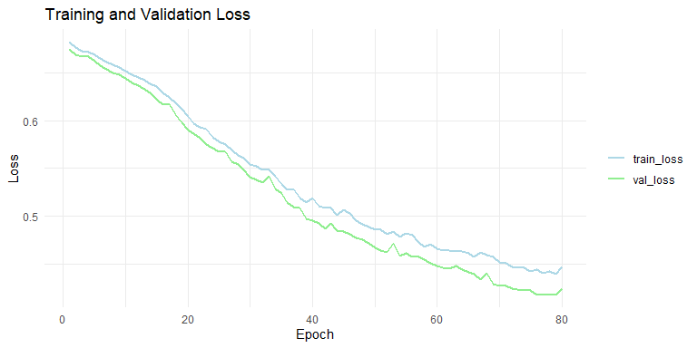

**modello B**

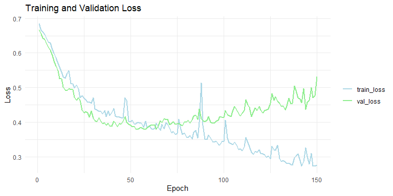

**modello C**

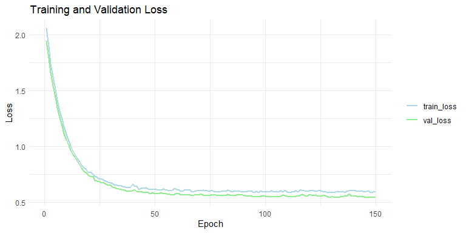

**modello D**

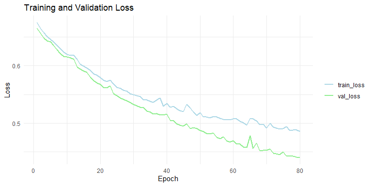

**modello E**

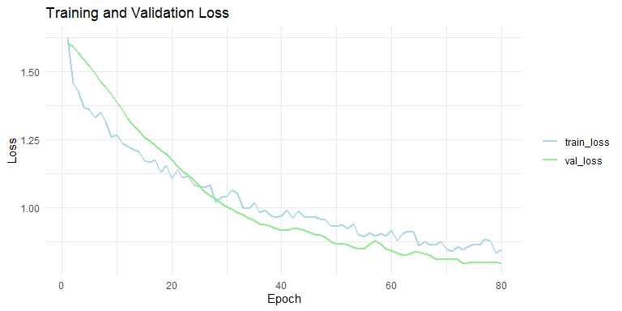

# 6 Accuracy Comparison

**modello A**

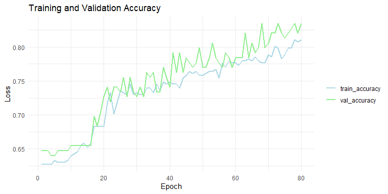

**modello B**

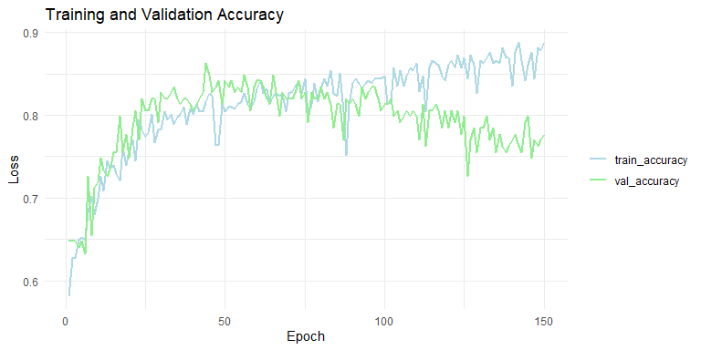

**modello C**

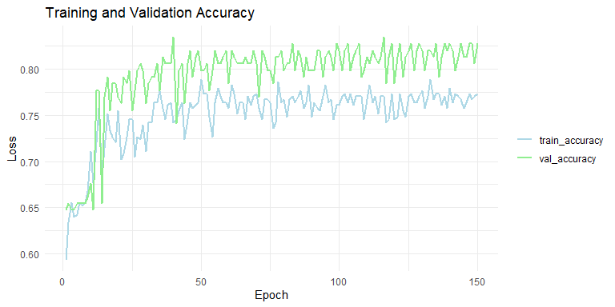

**modello D**

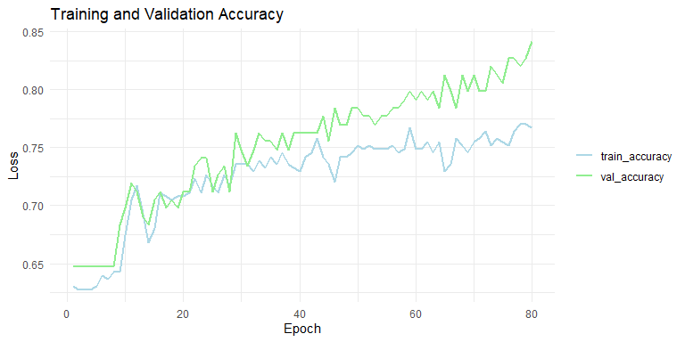

**modello E**

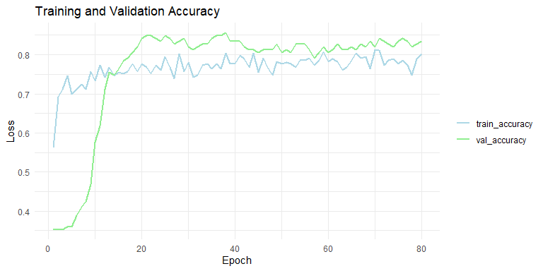

# 7 Scelta del modello ottimale

Osservando gli output forniti dai diversi modelli addestrati e i grafici presentati nelle due precedenti sezioni, possiamo giungere alle seguenti conclusioni:

- In generale, data la scarsità dei dati (solo 768 osservazioni), sembrerebbe che i modelli meno complessi in termini di layer nascosti e nodi (A, D, E) sembrano performare meglio rispetto al modello più complesso (B), evitando overfitting.
- Il modello più complesso in termini di numero di layer e nodi (B), overfitta in maniera evidente (si guardino i grafici dell’accuracy e della loss). Tuttavia, aggiungendo delle tecniche di riduzione dell’overfitting, come il kernel regularizer L2 e il Drop Out, la situazione migliora drasticamente (propri come presentato nel modello C).
- In conclusione, i modelli C ed E sembrerebbero essere quelli con le migliori performance.

# 8 Risultati sul test dataset

Di seguito sono riportati i risultati ottenuti in termini di Loss e Accuracy dei due migliori modelli (i.e., modello C e modello E).

```r
# results_train_C <- network_C %>%
#   evaluate(x_test, y_test)
#
# results_train_E <- network_E %>%
#   evaluate(x_test, y_test)
#
# list(E = results_train_E, C = results_train_C) %>%
#   saveRDS(paste0(getwd(), "/results.rds"))

results <- readr::read_rds(paste0(getwd(), "/results.rds"))

res_table <- tibble::tibble(
  measure = c("Loss", "Accuracy"),
  model_C = results$C,
  model_E = results$E
) %>%
  dplyr::mutate_if(is.numeric, ~round(., 4))

res_table %>%
  DT::datatable(
    options = list(
      dom = "t"
    )
  )
```

|  | measure | model_C | model_E |
| --- | --- | --- | --- |
| 1 | Loss | 0.5955 | 0.9292 |
| 2 | Accuracy | 0.759 | 0.7557 |

© Università della Calabria All Rights Reserved.